# Finding Fast Growing Firms

DA3 Assignment 2

Attila Szuts, Dominik Gulacsy

2/10/2021

[Github Repo](https://github.com/dgulacsy/da3-assignments/tree/main/da3-assignment2)

# Introduction

# Label engineering

# Data Cleaning/Wrangling

To conduct our analysis we used a dataset from the information company Bisnode. After creating a binary variable indicating a fast growing firm, we filtered down the data to the year 2012. We discarded firms which had more than 10 million or less than 1000 Euros in sales. We did this to only have quite normal (mid-sized, post-revenue) businesses in our sample. Using the available data extracted from general ledgers we calculated transformed variables and some financial ratios like the current ratio, asset turnover ratio, ROE and ROA.

# EDA

We investigated correlations between our predictors to see if there are any multicollinearity among them. Altough it is high, there was no perfect collinearity discovered.

# Model building

We are going to build two logistic regression models (one using logit the other probit as their link function), an elastic net regularized regression model, a K-nearest neighbor classificator, a random forest model and finally a gradient boosting machine. Each model will be cross validated 10 times using the same sample, and the top 3 model will be selected based on the highest cross-validated ROC value. We will use these models to find the optimal threshold according to a pre-determined loss function and compare the expected loss between the models. Finally we will evaluate model performance on a test sample.

# Choose Top 3 Probability Prediction Models based on AUC

Based on the CV ROC performance of our six models, we chose GBM, random forest and logistic regression with logit link function.

Their CV performance can be seen in this table.

|  | ROC |
| --- | --- |
| logit | 0.668 |
| probit | 0.664 |
| elastic | 0.606 |
| rf | 0.703 |
| gbm | 0.710 |
| knn | 0.553 |

Without defining a loss function we checked whether our best models were appropriately callibrated using callibration curves, that you can take a look at below.

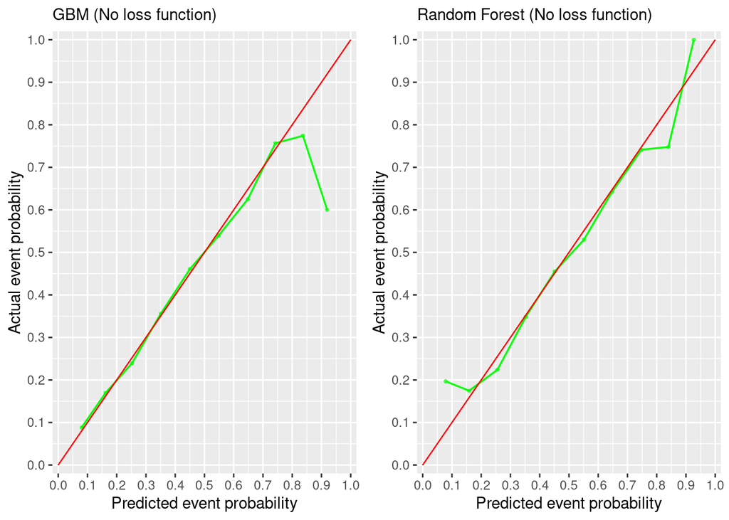

# Run classification with loss function

Next, we ran a cross validation on choosing the loss function with the minimal expected loss. The results can be seen in this table.

|  | CV.AUC | Avg.of.optimal.thresholds | Threshold.for.Fold5 | Avg.expected.loss | Expected.loss.for.Fold5 |
| --- | --- | --- | --- | --- | --- |
| gbm | 0.7103605 | 0.5265701 | 0.5194852 | 0.3662013 | 0.3620711 |
| rf | 0.7028690 | 0.5364000 | 0.5350000 | 0.3648115 | 0.3693511 |
| logit | 0.6681022 | 0.5317851 | 0.5443537 | 0.3879934 | 0.3873339 |

# Test model performance

| model | Test.RMSE | Test.AUC | Avg..Exp..Loss |
| --- | --- | --- | --- |
| GBM | 0.4645571 | 0.7040723 | 0.445276 |